# Electric Vehicles Final Project Stat184

Owen McInerney, Eric Best, Anirudh Kumar

2023-11-20

## Introduction

Electric vehicles, once a rarity, are now a common sight on America’s roads and all over the world. Here in State College, Teslas, Rivians, and other electric vehicles from traditional car manufacturers are fairly common. Our group wanted to investigate the viability of owning an electric vehicle. We wanted to examine some questions regarding these cars. If we went on a road trip, where could we find charging stations? How far could we go on a full-charge? How do these vehicles compare when considering the pricetag and the excursion range? And, with regards to general global trends with EV’s, how has their adoption changed over time? Which countries are embracing electric vehicles? We will also compare statistics between EV’s and gas-powered vehicles.

## Research Questions

1. How common are charging stations in Pennsylvania for public use?
2. What vehicle has the longest excursion time/length on a full-charge?
3. How do EV manufacturers compare in excursion range and vehicle price?
4. How has global EV usage changed over the years?
5. Which countries lead in EV usage? Which countries are lagging behind?
6. How do Electric Vehicles and Gas Vehicles compare in MPGe?
7. How do costs differ between electric vehicles and gas vehicles?

# Exploratory Datasets

1. Jeff Swanson’s EV Dataset
   - Used to get a general idea of EV cars and their characteristics
   - Does not appear in data visualizations
2. New York State EV Rebate Program Dataset
   - Used to investigate rebate programs, which impacts economic viability
   - Does not appear in data visualizations
3. Washington State EV Database:
   - Exploratory dataset used to learn about MSRP, excursion time using a full charge, etc
   - Does not appear in data visualizations

# Datasets used for Visualizations

4. Alternative Fueling Stations Dataset
   - Includes information on charging stations throughout the USA and Canada
   - Cases: A charging station
   - Attributes: Fuel.Type.Code, State, Groups.With.Access.Code, Latitude, Longitude
5. International Energy Agency
   - Global EV 2023 Outlook CSV
     - Cases: a given setting
     - Attributes: year, month, region EV sales, EV Stock, EV type
6. US Department of Energy
   - 2024 vehicles to assess energy efficiency of different vehicles excel file
   - Cases: vehicle
   - Attributes: model, fuel type, city mpge (miles per gallon equivalent), highway mpge equivalent, greenhouse gas score, CO2 emissions, vehicle size
7. Bureau of Labor Statistics
   - 2022 Electricity prices by month per kWh excel file
     - Cases: energy type
     - Attributes: energy type, January average price, February average price, etc.
   - 2022 Unleaded Regular Gas Price per gallon
     - Cases: energy type
     - Attributes: energy type, January average price, February average price, etc.

## Data Wrangling

1. For Question 1, the data.gov dataset is already tidied. We want only the attributes Fuel.Type.Code, State, Groups.With.Access.Code, Latitude, Longitude. These attributes will help us show a map of publicly available charging stations in Pennsylvania.
2. For Question 2, we tidied the dataset to include only the attributes as follows: Automobile.ID, Fuel, Manufacturer.ID, Manufacturer, Model, Model.Year,Category.ID, Engine.Type, Engine.Size, Transmission.Type, Category, Engine.Size, City.Fuel.Economy.Units, City.Fuel.Economy, Highway.Fuel.Economy.Units, Highway.Fuel.Economy.
3. For Question 3, we already had tidied data for EV’s. The desired attributes are Price and Range.
4. For Question 4, we wanted to change the IEA dataset from a case of a given setting to a given year. The attributes we wanted were the year and the count of electric vehicles supplied in that year.
5. For Question 5, we wanted to change the IEA dataset from a case of a given setting to a given region. The attributes we wanted was the region and the count of electric vehicles supplied in that region between 2019 and 2022.
6. For Question 6, we wanted to change to preserve the case of a car, but only take attributes: model, fuel type, vehicle size, air pollution score, city mpge, highway mpge, combined mpge, and greenhouse gas score.
7. For Question 7, we wanted to join the tables the Bureau of Labor Statistics for electric and gas costs and change the case from an energy type to a month with the attributes: month, fuel type, and miles per dollar.

## Question 1: How common are charging stations in Pennsylvania for public use?

Our group wanted to examine charging stations in Pennsylvania. If we know where stations are, we can get a general idea of how we can drive an EV around Pennsylvania. We used the Alternative Fueling Stations 2021 Dataset, which is already tidy. Our cases are defined as a charging station in America. The original dataset includes a lot of attributes but we only need the Station Name, its State, its Longitude, and its Latitude. Also important to consider is whether the station is available for public use. Many charging stations are only for municipal workers, law enforcement, etc.

We can see from the Leaflet map that charging stations are common in PA, especially as one travels along the US highway system. To be exact, there are $931$ charging stations available for civilian use in this state, with some present in State College, Harrisburg, Pittsburgh, and Philadelphia. Clearly, the northern part of the state has the fewest stations but that will probably change in time.

[interactive chart not shown]

Next, we’ll examine fuel economy for EV SUV’s, Sedans/Wagons, and Vans. This is probably one of the most important factors to consider when looking at electric vehicles. The dataset is a tidied list of electric vehicles, with some relevant attributes like Highway Fuel Economy. As we can see from the table, Sedans generally outclass SUV’s and Vans for fuel economy. Indeed, the average fuel economy for a Sedan is $97.5625$, placing this category above SUV’s and far above Vans.

| EV Highway Economy, in MPGe Category | EV Highway Economy, in MPGe Minimum | EV Highway Economy, in MPGe 1st Quartile | EV Highway Economy, in MPGe 2nd Quartile | EV Highway Economy, in MPGe Median | EV Highway Economy, in MPGe 3rd Quartile | EV Highway Economy, in MPGe 4th Quartile | EV Highway Economy, in MPGe Max | EV Highway Economy, in MPGe Mean | EV Highway Economy, in MPGe Standard Deviation | EV Highway Economy, in MPGe # of Vehicles |
| --- | --- | --- | --- | --- | --- | --- | --- | --- | --- | --- |
| SUV | 74 | 74 | 74 | 74 | 74 | 74 | 74 | 74.0000 | 0.0000 | 2 |
| Sedan/Wagon | 68 | 92 | 99 | 99 | 99 | 105 | 109 | 97.5625 | 10.1454 | 16 |
| Van | 62 | 62 | 62 | 62 | 62 | 62 | 62 | 62.0000 | NA | 1 |

<sup>a</sup> MPGe: Miles Per Gallon equivalent. This measures an EV’s efficiency against gasoline vehicles

## Question 3: How do EV manufacturers compare by price and EPA for their products?

Below, we have reproduced a scatter plot that has EV’s from a variety of manufacturers. It turns out that price and EPA are not strongly correlated, so people can reliably find a car with a good EPA for a reasonable price. We can see from the scatter plot that an expensive car doesn’t necessarily have a high EPA.

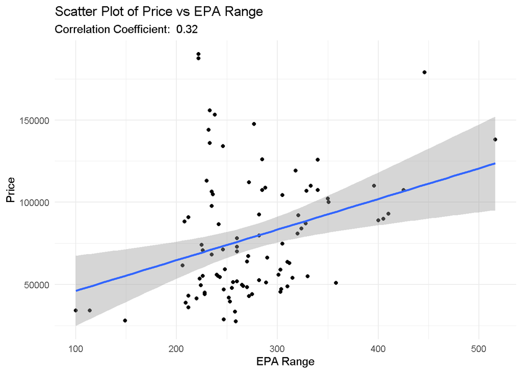

## Question 4: How has the global supply of electric vehicles changed over the years?

Around 1900, steam vehicles, gas vehicles, and electric vehicles were all competitive with each other. Gas vehicles were more difficult to drive, while electric vehicles were easier to drive. With electricity becoming more popular in homes, electric vehicles became a viable option for short trips. However, when Henry Ford came out with the Model T, which cost only $650 per car, electric cars could not compete at $1750 per car. The world became accustomed to gas-powered vehicles, and gas still is the most common fuel source for vehicles.

As science developed, electric cars have became cheaper and more efficient. In addition climate change, partially induced by gas-powered vehicles, has been a reason to make the switch to electric vehicles. Another reason for the switch to electric vehicles, in sudden gas shortages caused by war and dependence on other countries. Our group wanted to investigate how global EV supply has changed over the year. Using the 2023 Global EV Outlook data set from the International Energy Agency, we were able to examine the change in the supply of electric vehicles over the years. From the bar chart below, we can see that the quantity of electric vehicles’ supplied has increased exponentially each year since 2010. We can predict from this that there will be another significant increase in electric vehicles supplied for 2023.

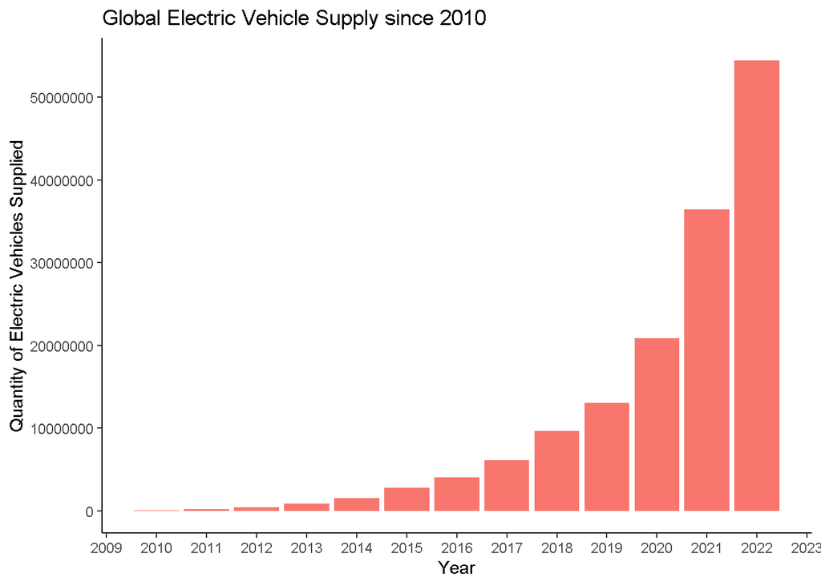

## Question 5: Which countries lead in EV usage? Which countries are lagging behind?

Similar to the race to the moon, different regions are trying to adapt quickly to the need for electric vehicles. Our group wanted to investigate which countries lead in the race to the adaption to electric vehicles. We also wanted to see which regions implemented electric vehicles the least.

From the bar chart below, we can see that China have the greatest quantity of electric vehicles supplied. This might be due to the fact that they are the most populated region in the world. It also may be due to their lack of child labor laws, which would allow them to increase production at a smaller cost. We can also see that Turkey, South Africa, and Chile have implemented electric cars the least. This is likely due to their economies not being as strong as China’s or the United States.

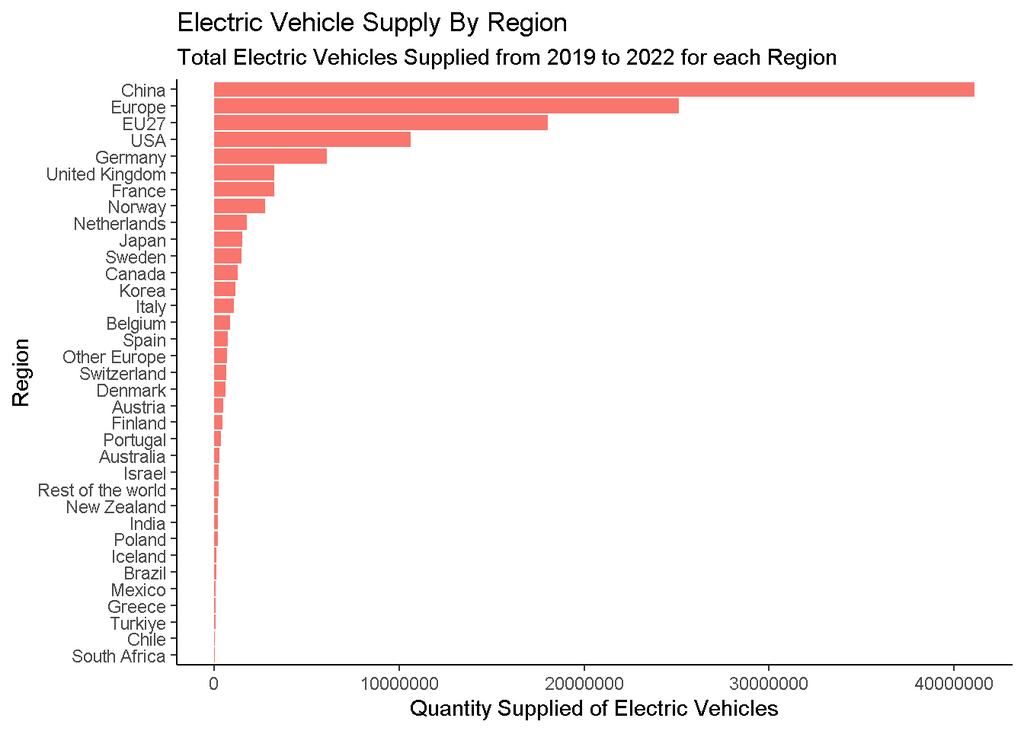

## Question 6: How do Electric Vehicles and Gas Vehicles compare in MPGe?

Our group wanted to investigate whether gas-powered vehicles or electric vehicles were more efficient. We decided to make a box plot of the miles per gallon equivalent (mpge) (where 33.7 kWh = 1 gallon) for gas-powered vehicles and electric vehicles.

In the box plot below, we can see that electric vehicles tend to have a higher mpge than gas-powered vehicles. This may be due to investment in electric vehicles which has allowed for quick advancement in the range of electric vehicles. Also, electric vehicles directly convert a kilowatt hour to motion while gas-powered vehicle convert gas into heat which then creates motion.

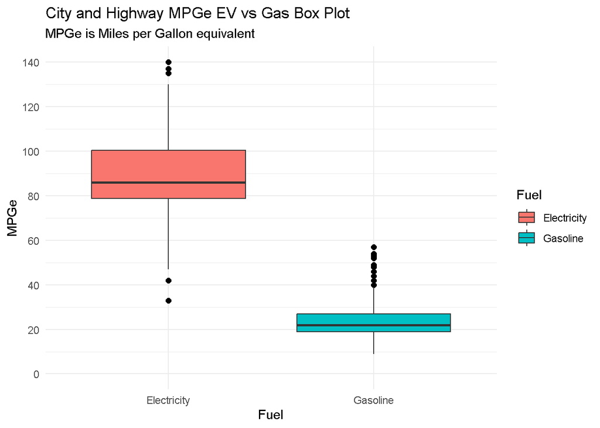

## Question 7: How do costs differ between electric vehicles and gas vehicles?

After seeing that electric vehicles tend to have a greater miles per gallon equivalent than gas-powered vehicles, we wanted to see which was more cost effective. We decided to take date from the Bureau of Labor Statistics for energy costs each month during 2022 (because 2023 has not finished yet). We also took the average mpge from the 2024 vehicles tested by the US department of energy. We then divided the mpge by the energy costs for each month and fuel type.

We can see from the line graph below that an electric vehicle will go further distance per dollar of energy than a gas-powered vehicle. This is due to electric vehicles having nearly four times the average mpge than a gas-powered vehicle. Future evaluations should include costs to purchase the vehicles and costs of maintaining the vehicles.

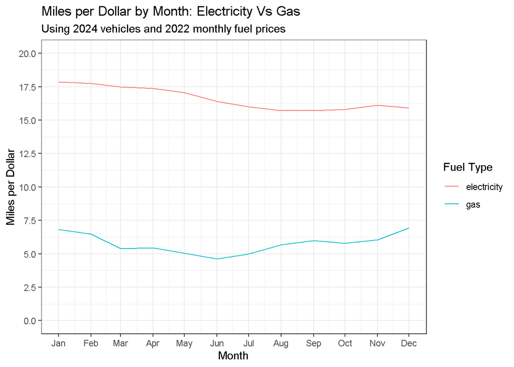

## Conclusion

In Question 4, we saw that manufacturers are ramping up supply to meet increasing demands for these cars. Then, in Question 5, we examined a chart showing which countries are falling in love with EV’s - America, China, and members of the EU. We can see that other countries such as Greece and Chile have yet to adopt these cars. In Question 6, we introduced a measurement of EV fuel efficiency called MPGe, and found that EV’s outclass gasoline vehicles in this metric. Lastly, in Question 7, we showed a graph that suggests EV’s are far more economical than conventional cars on a miles-per-dollar basis.

When we consider all of these factors, it’s clear that electric vehicles are here to stay.

## Code Appendix

```r
knitr::opts_chunk$set(echo = FALSE)
# Style of Choice -- TidyVerse Styling
library(groundhog)
groundhog.day <- "2023-11-20"
pkgs <- c("here", "dplyr", "dbplyr", "ggplot2", "readxl", "tidyverse", "knitr", "kableExtra", "leaflet")
groundhog.library(pkgs, groundhog.day)
# Ensures scientific notation is not used
options(scipen = 999)

# Alternative Fueling Stations Data for Q1
csv_path <- here("EVfuelstations.csv")
EVfuelstations <- read.csv(csv_path)

# EVcars Data for Q2
csv_path <- here("EVcars.csv")
EVcars <- read.csv(csv_path)

# Dataset for Q3
csv_path <- here("EVrange_value_General.csv")
EV_range_value_General <- read.csv(csv_path)

# IEA csv File for Q4 and Q5
csv_path <- here("IEA_EV_SalesHistoricalCars.csv")
EV_Global_Historical_raw <- read.csv(csv_path)

# US department of Energy xlsx File for Q6
EV_GAS_data_raw <- read_excel("all_alpha_24.xlsx")

# BLS Data on Fuel Prices xlsx File for Q7
gas_prices <- read_excel("bls_gas_prices.xlsx", range = "B11:M11", col_names = FALSE)
electricty_prices <- read_excel("bls_electricity_prices.xlsx", range = "B11:M11", col_names = FALSE)
# Wrangle Data ---------------------------------------------------------------
# Q1: How common are charging stations in Pennsylvania for public use?

filtered_stations <- EVfuelstations %>%
  filter(Fuel.Type.Code == "ELEC") %>%
  filter(State == "PA") %>%
  filter(Groups.With.Access.Code == 'Public')

# Printing the number of stations in Pennsylvania
num_stations <- nrow(filtered_stations)
print("Number of Public EV Charging Stations in PA:")
print(num_stations)

# The station names and coordinates are easily selected
stationNames <- filtered_stations$Station.Name
latitude <- filtered_stations$Latitude
longitude <- filtered_stations$Longitude

# Create a custom data frame with station coordinates and names
# Leaflet is sensitive to large datasets
station_data <- data.frame(
  Name <- stationNames,
  Latitude <- latitude,
  Longitude <- longitude
)
# ---------------------------------------------------------------

# Q2: What vehicle has the longest excursion time/length on a full-charge?
# We have a lot of attributes to pull in. They are as follows:
EVcars_tidy <- EVcars %>%
  filter(Fuel.ID == 41) %>%
  select(Automobile.ID, Fuel, Manufacturer.ID, Manufacturer, Model,
         Model.Year,Category.ID, Engine.Type, Engine.Size, Transmission.Type,
         Category, Engine.Size, City.Fuel.Economy.Units, City.Fuel.Economy,
         Highway.Fuel.Economy.Units, Highway.Fuel.Economy)

# filters to cases where fuel economy is measured in mpge and is a sedan/wagon
EVcars_mpge <- EVcars_tidy %>%
  filter(City.Fuel.Economy.Units == 'mpge')
# ---------------------------------------------------------------

# Q3: How do EV manufacturers compare in excursion range and vehicle price?

# Need to change name of EPA range attribute to access
colnames(EV_range_value_General)[5] <- "EPA_range_mi"

# Wangling Data to have case: electric vehicle and attribute: price and epa range
EV_range_value_df <- EV_range_value_General %>%
  mutate(Price = as.numeric(gsub(",", "", Price))) %>%
  select(Price, EPA_range_mi, Make)

# ---------------------------------------------------------------

# Q4: wrangle IEA data to cases of years with attributes: year, count of EVs

EV_supply_global_year <- EV_Global_Historical_raw %>%
  filter(unit == "Vehicles", region != "World") %>%
  select(year, value) %>%
  group_by(year) %>%
  summarise(count = sum(value))

# ---------------------------------------------------------------

#  Q5: wrangle IEA data to get cases of regions from 2019-2022 with attributes: region, count of EVs
EV_supply_region_2019_2022 <- EV_Global_Historical_raw %>%
  filter(unit == "Vehicles", region != "World", year >= 2019) %>%
  select(region, value) %>%
  group_by(region) %>%
  summarise(count = sum(value))

# ---------------------------------------------------------------

# Q6: US department of energy data: only want to include Model, fuel, veh_class, air pollution score, city mpg, highway mpg,  greenhouse gas score

# Change names of columns with spaces
colnames(EV_GAS_data_raw)[11] <- "veh_class"
colnames(EV_GAS_data_raw)[12] <- "air_pollution_score"
colnames(EV_GAS_data_raw)[13] <- "city_mpge"
colnames(EV_GAS_data_raw)[14] <- "highway_mpge"
colnames(EV_GAS_data_raw)[15] <- "cmb_mpge"
colnames(EV_GAS_data_raw)[16] <- "greenhouse_gas_score"

# Cases are cars with attributes: Model, fuel, vehicle class, air pollution score, city mpg, highway mpg, greenhouse gas score
EV_GAS_data <- EV_GAS_data_raw %>%
  drop_na(city_mpge) %>%
  filter(Fuel == "Gasoline" | Fuel == "Electricity") %>%
  select(Model, Fuel, veh_class, air_pollution_score, city_mpge, highway_mpge, cmb_mpge, greenhouse_gas_score) %>%
  mutate(
    city_mpge = as.numeric(city_mpge),
    highway_mpge = as.numeric(highway_mpge),
    cmb_mpge = as.numeric(cmb_mpge),
    greenhouse_gas_score = as.numeric(greenhouse_gas_score)
  )

# ---------------------------------------------------------------

# Q7: BLS Data + US department of energy data: case = a month with attribute: month, miles per gallon equivalent for fuel and electricity
electricty_prices[1:12] <- electricty_prices[1:12] * 33.7 # converts from kWh to kWh equivalent of a gallon
fuel_df <- full_join(gas_prices, electricty_prices)

# Currently have each month as a given column: need to label columns
colnames(fuel_df)[1] <- "jan"
colnames(fuel_df)[2] <- "feb"
colnames(fuel_df)[3] <- "mar"
colnames(fuel_df)[4] <- "apr"
colnames(fuel_df)[5] <- "may"
colnames(fuel_df)[6] <- "jun"
colnames(fuel_df)[7] <- "jul"
colnames(fuel_df)[8] <- "aug"
colnames(fuel_df)[9] <- "sep"
colnames(fuel_df)[10] <- "oct"
colnames(fuel_df)[11] <- "nov"
colnames(fuel_df)[12] <- "dec"

# To find average mpge for gas and electric
mpge_avg_fuel <- EV_GAS_data %>%
  group_by(Fuel) %>%
  summarise(mpge_avg = mean(cmb_mpge))

electricity_price_per_mile <- mpge_avg_fuel %>%
  filter(Fuel == "Electricity") %>%
  select(mpge_avg)

gas_price_per_mile <- mpge_avg_fuel %>%
  filter(Fuel == "Gasoline") %>%
  select(mpge_avg)

# Make sure they are numeric
electricity_avg_mpge <- as.numeric(electricity_price_per_mile)
gas_avg_mpge <- as.numeric(gas_price_per_mile)

# Add fuel type column to data frame
fuel_df$type <- c("gas", "electricity")

# Need to change cases to months
fuel_df <- fuel_df %>%
  pivot_longer(
    cols = c(jan, feb, mar, apr, may, jun, jul, aug, sep, oct, nov, dec),
    names_to = "month",
    values_to = "avg_gallon_equaivalent_price"
  )

# Making actual dates instead of character dates
dates <- append(
  seq(from = as.Date("2022-01-01"), to = as.Date("2022-12-01"), by = "month"),
  seq(from = as.Date("2022-01-01"), to = as.Date("2022-12-01"), by = "month")
)

# Add dates column to fuel_df
fuel_df$date <- dates

# do not need month column anymore, want to mutate from avg price per gallon to miles per dollar
fuel_df <- fuel_df %>%
  select(type, avg_gallon_equaivalent_price, date) %>%
  mutate(miles_per_dollar = case_when(
    type == "gas" ~ gas_avg_mpge / avg_gallon_equaivalent_price,
    type == "electricity" ~ electricity_avg_mpge / avg_gallon_equaivalent_price
  )) %>%
  select(date, type, miles_per_dollar)
# Create the leaflet map
EVchargemap <- leaflet(station_data) %>%
  setView(lng = -77.8124, lat = 40.86833, zoom = 6) %>%
  addTiles() %>%
  addMarkers(lat = ~Latitude, lng = ~Longitude, popup = ~Name)

# Display the map
EVchargemap
funx <- list(
  min = ~min(.x, na.rm = TRUE),
  Q1 = ~quantile(.x, probs = 0.20, na.rm = TRUE),
  Q2 = ~quantile(.x, probs = 0.40, na.rm = TRUE),
  median = ~median(.x, na.rm = TRUE),
  Q3 = ~quantile(.x, probs = 0.60, na.rm = TRUE),
  Q4 = ~quantile(.x, probs = 0.80, na.rm = TRUE),
  max = ~max(.x, na.rm = TRUE),
  mean = ~mean(.x, na.rm = TRUE),
  std = ~sd(.x, na.rm = TRUE)
)

EVcars_mpge_CityHighway_FiveNumSum <- EVcars_mpge %>%
  group_by(Category) %>%
  select(Category, City.Fuel.Economy, Highway.Fuel.Economy) %>%
  summarize(
    across(
      .cols=where(is.numeric),
      .fns = funx),
    count =n()
  )
EVcars_mpge_CityHighway_FiveNumSum <- setNames(EVcars_mpge_CityHighway_FiveNumSum,
                                               c("Category", "Minimum", "1st Quartile", "2nd
                                                 Quartile", "Median", "3rd Quartile", "4th Quartile","Max", "Mean", "Standard Deviation", "# of Vehicles"))

# Display Table ---------------------------
EVcars_mpge_CityHighway_FiveNumSum %>%
  kable() %>%
  kableExtra::kable_classic() %>%
  add_header_above(c("EV Highway Economy, in MPGe" = 11))%>%
  add_footnote("MPGe: Miles Per Gallon equivalent. This measures an EV's efficiency against gasoline vehicles")
# Create a scatter plot
EPA_range_by_make_linear_scatter_plot <- ggplot(EV_range_value_df, aes(x = EPA_range_mi, y = Price)) +
  geom_point() +
  geom_smooth(method = 'lm') +
  labs(
    title = "Scatter Plot of Price vs EPA Range",
    subtitle = paste("Correlation Coefficient: ", round(cor(EV_range_value_df$Price, EV_range_value_df$EPA_range_mi), 2)),
    x = "EPA Range",
    y = "Price"
  ) +
  theme_minimal()

EPA_range_by_make_linear_scatter_plot
# Create Bar Chart of Global EV Ownership by Year -----------------------------
global_ev_supply_by_year_bar_chart <- ggplot(EV_supply_global_year, aes(x = year, y = count, fill = "red")) +
  geom_col() +
  scale_y_continuous(n.breaks = 8, limits = c(0, max(EV_supply_global_year$count))) +
  scale_x_continuous(n.breaks = 11) +
  labs(
    title = "Global Electric Vehicle Supply since 2010",
    x = "Year",
    y = "Quantity of Electric Vehicles Supplied"
  ) +
  theme_classic() +
  theme(legend.position = "none") # removes legend

# View Global EV supply by year Bar Chart
global_ev_supply_by_year_bar_chart
# Create bar chart of EV Ownership by Country ---------------------------------
# use y = reorder(region, +count) to order countries by car ownership
regional_ev_supply_bar_chart <- ggplot(EV_supply_region_2019_2022, aes(x = count, y = reorder(region, +count), fill = "red")) +
  geom_col() +
  scale_x_continuous(limits = c(0, max(EV_supply_region_2019_2022$count)), n.breaks = 6) +
  labs(
    title = "Electric Vehicle Supply By Region",
    subtitle = "Total Electric Vehicles Supplied from 2019 to 2022 for each Region",
    x = "Quantity Supplied of Electric Vehicles",
    y = "Region"
  ) +
  theme_classic() +
  theme(legend.position = "none") # removes legend

# View Regional EV Supply Bar Chart
regional_ev_supply_bar_chart
# Make Box Plots -------------------------------------------------------------
# Combined MPGe Box Plot
combined_mpge_box_plot <- EV_GAS_data %>%
  group_by(Fuel) %>%
  ggplot(aes(x = Fuel, y = cmb_mpge, group = Fuel, fill = Fuel)) +
  labs(title = "City and Highway MPGe EV vs Gas Box Plot", subtitle = "MPGe is Miles per Gallon equivalent", x = "Fuel", y = "MPGe") +
  scale_y_continuous(n.breaks = 10, limits = c(0, max(EV_GAS_data$cmb_mpge))) +
  geom_boxplot(
    outlier.colour = "black", outlier.shape = 16,
    outlier.size = 2, notch = FALSE
  ) +
  theme_minimal()

# View Combined MPGe Box Plot
combined_mpge_box_plot
# Make Line Graph ------------------------------------------------------------
miles_per_dollar_line_graph <- fuel_df %>%
  ggplot(aes(x = date, y = miles_per_dollar, color = type)) +
  geom_line() +
  scale_y_continuous(n.breaks = 10, limits = c(0, 20)) +
  scale_x_date(date_breaks = "1 month", date_labels = "%b") +
  labs(
    title = "Miles per Dollar by Month: Electricity Vs Gas",
    subtitle = "Using 2024 vehicles and 2022 monthly fuel prices",
    x = "Month", y = "Miles per Dollar", color = "Fuel Type"
  ) +
  theme_bw()

# View Miles per Dollar Line Graph
miles_per_dollar_line_graph
```